# Risk Factor Analysis

## Outcome Variable

**Outcome Variable:** wast_rec90d

## Predictor Variables

**Intervention Variable:** perdiar6

**Adjustment Set:**

- arm
- sex
- W_mage
- meducyrs
- hfoodsec
- W_mhtcm
- W_mwtkg
- W_mbmi
- W_birthwt
- W_birthlen
- W_nrooms
- month
- brthmon
- impfloor
- impsan
- safeh20
- delta_W_mage
- delta_meducyrs
- delta_hfoodsec
- delta_W_mhtcm
- delta_W_mwtkg
- delta_W_mbmi
- delta_W_birthwt
- delta_W_birthlen
- delta_W_nrooms
- delta_month
- delta_brthmon
- delta_impfloor
- delta_impsan
- delta_safeh20

## Stratifying Variables

The analysis was stratified on these variable(s):

- agecat
- studyid
- country

## Data Summary

| agecat | studyid | country | perdiar6 | wast_rec90d | n_cell | n |
| --- | --- | --- | --- | --- | --- | --- |
| 0-24 months | ki0047075b-MAL-ED | BANGLADESH | 0% | 0 | 16 | 124 |
| 0-24 months | ki0047075b-MAL-ED | BANGLADESH | 0% | 1 | 22 | 124 |
| 0-24 months | ki0047075b-MAL-ED | BANGLADESH | (0%, 5%] | 0 | 20 | 124 |
| 0-24 months | ki0047075b-MAL-ED | BANGLADESH | (0%, 5%] | 1 | 34 | 124 |
| 0-24 months | ki0047075b-MAL-ED | BANGLADESH | >5% | 0 | 8 | 124 |
| 0-24 months | ki0047075b-MAL-ED | BANGLADESH | >5% | 1 | 24 | 124 |
| 0-24 months | ki0047075b-MAL-ED | BRAZIL | 0% | 0 | 5 | 24 |
| 0-24 months | ki0047075b-MAL-ED | BRAZIL | 0% | 1 | 16 | 24 |
| 0-24 months | ki0047075b-MAL-ED | BRAZIL | (0%, 5%] | 0 | 0 | 24 |
| 0-24 months | ki0047075b-MAL-ED | BRAZIL | (0%, 5%] | 1 | 2 | 24 |
| 0-24 months | ki0047075b-MAL-ED | BRAZIL | >5% | 0 | 1 | 24 |
| 0-24 months | ki0047075b-MAL-ED | BRAZIL | >5% | 1 | 0 | 24 |
| 0-24 months | ki0047075b-MAL-ED | INDIA | 0% | 0 | 14 | 181 |
| 0-24 months | ki0047075b-MAL-ED | INDIA | 0% | 1 | 29 | 181 |
| 0-24 months | ki0047075b-MAL-ED | INDIA | (0%, 5%] | 0 | 35 | 181 |
| 0-24 months | ki0047075b-MAL-ED | INDIA | (0%, 5%] | 1 | 50 | 181 |
| 0-24 months | ki0047075b-MAL-ED | INDIA | >5% | 0 | 22 | 181 |
| 0-24 months | ki0047075b-MAL-ED | INDIA | >5% | 1 | 31 | 181 |
| 0-24 months | ki0047075b-MAL-ED | NEPAL | 0% | 0 | 12 | 98 |
| 0-24 months | ki0047075b-MAL-ED | NEPAL | 0% | 1 | 31 | 98 |
| 0-24 months | ki0047075b-MAL-ED | NEPAL | (0%, 5%] | 0 | 2 | 98 |
| 0-24 months | ki0047075b-MAL-ED | NEPAL | (0%, 5%] | 1 | 23 | 98 |
| 0-24 months | ki0047075b-MAL-ED | NEPAL | >5% | 0 | 6 | 98 |
| 0-24 months | ki0047075b-MAL-ED | NEPAL | >5% | 1 | 24 | 98 |
| 0-24 months | ki0047075b-MAL-ED | PERU | 0% | 0 | 3 | 35 |
| 0-24 months | ki0047075b-MAL-ED | PERU | 0% | 1 | 8 | 35 |
| 0-24 months | ki0047075b-MAL-ED | PERU | (0%, 5%] | 0 | 1 | 35 |
| 0-24 months | ki0047075b-MAL-ED | PERU | (0%, 5%] | 1 | 6 | 35 |
| 0-24 months | ki0047075b-MAL-ED | PERU | >5% | 0 | 2 | 35 |
| 0-24 months | ki0047075b-MAL-ED | PERU | >5% | 1 | 15 | 35 |

[output cut: 204 more lines]

The following strata were considered:

- agecat: 0-24 months, studyid: ki0047075b-MAL-ED, country: BANGLADESH
- agecat: 0-24 months, studyid: ki0047075b-MAL-ED, country: BRAZIL
- agecat: 0-24 months, studyid: ki0047075b-MAL-ED, country: INDIA
- agecat: 0-24 months, studyid: ki0047075b-MAL-ED, country: NEPAL
- agecat: 0-24 months, studyid: ki0047075b-MAL-ED, country: PERU
- agecat: 0-24 months, studyid: ki0047075b-MAL-ED, country: SOUTH AFRICA
- agecat: 0-24 months, studyid: ki0047075b-MAL-ED, country: TANZANIA, UNITED REPUBLIC OF
- agecat: 0-24 months, studyid: ki1000109-EE, country: PAKISTAN
- agecat: 0-24 months, studyid: ki1017093-NIH-Birth, country: BANGLADESH
- agecat: 0-24 months, studyid: ki1017093b-PROVIDE, country: BANGLADESH
- agecat: 0-24 months, studyid: ki1017093c-NIH-Crypto, country: BANGLADESH
- agecat: 0-24 months, studyid: ki1114097-CMIN, country: BANGLADESH
- agecat: 0-24 months, studyid: ki1114097-CONTENT, country: PERU
- agecat: 0-6 months, studyid: ki0047075b-MAL-ED, country: BANGLADESH
- agecat: 0-6 months, studyid: ki0047075b-MAL-ED, country: BRAZIL
- agecat: 0-6 months, studyid: ki0047075b-MAL-ED, country: INDIA
- agecat: 0-6 months, studyid: ki0047075b-MAL-ED, country: NEPAL
- agecat: 0-6 months, studyid: ki0047075b-MAL-ED, country: PERU
- agecat: 0-6 months, studyid: ki0047075b-MAL-ED, country: SOUTH AFRICA
- agecat: 0-6 months, studyid: ki0047075b-MAL-ED, country: TANZANIA, UNITED REPUBLIC OF
- agecat: 0-6 months, studyid: ki1000109-EE, country: PAKISTAN
- agecat: 0-6 months, studyid: ki1017093-NIH-Birth, country: BANGLADESH
- agecat: 0-6 months, studyid: ki1017093b-PROVIDE, country: BANGLADESH
- agecat: 0-6 months, studyid: ki1017093c-NIH-Crypto, country: BANGLADESH
- agecat: 0-6 months, studyid: ki1114097-CMIN, country: BANGLADESH
- agecat: 0-6 months, studyid: ki1114097-CONTENT, country: PERU
- agecat: 6-24 months, studyid: ki0047075b-MAL-ED, country: BANGLADESH
- agecat: 6-24 months, studyid: ki0047075b-MAL-ED, country: BRAZIL
- agecat: 6-24 months, studyid: ki0047075b-MAL-ED, country: INDIA
- agecat: 6-24 months, studyid: ki0047075b-MAL-ED, country: NEPAL
- agecat: 6-24 months, studyid: ki0047075b-MAL-ED, country: PERU
- agecat: 6-24 months, studyid: ki0047075b-MAL-ED, country: SOUTH AFRICA
- agecat: 6-24 months, studyid: ki0047075b-MAL-ED, country: TANZANIA, UNITED REPUBLIC OF
- agecat: 6-24 months, studyid: ki1000109-EE, country: PAKISTAN
- agecat: 6-24 months, studyid: ki1017093-NIH-Birth, country: BANGLADESH
- agecat: 6-24 months, studyid: ki1017093b-PROVIDE, country: BANGLADESH
- agecat: 6-24 months, studyid: ki1017093c-NIH-Crypto, country: BANGLADESH
- agecat: 6-24 months, studyid: ki1114097-CMIN, country: BANGLADESH
- agecat: 6-24 months, studyid: ki1114097-CONTENT, country: PERU

### Dropped Strata

Some strata were dropped due to rare outcomes:

- agecat: 0-24 months, studyid: ki0047075b-MAL-ED, country: BRAZIL
- agecat: 0-24 months, studyid: ki0047075b-MAL-ED, country: NEPAL
- agecat: 0-24 months, studyid: ki0047075b-MAL-ED, country: PERU
- agecat: 0-24 months, studyid: ki0047075b-MAL-ED, country: SOUTH AFRICA
- agecat: 0-24 months, studyid: ki0047075b-MAL-ED, country: TANZANIA, UNITED REPUBLIC OF
- agecat: 0-24 months, studyid: ki1000109-EE, country: PAKISTAN
- agecat: 0-24 months, studyid: ki1114097-CONTENT, country: PERU
- agecat: 0-6 months, studyid: ki0047075b-MAL-ED, country: BANGLADESH
- agecat: 0-6 months, studyid: ki0047075b-MAL-ED, country: BRAZIL
- agecat: 0-6 months, studyid: ki0047075b-MAL-ED, country: NEPAL
- agecat: 0-6 months, studyid: ki0047075b-MAL-ED, country: PERU
- agecat: 0-6 months, studyid: ki0047075b-MAL-ED, country: SOUTH AFRICA
- agecat: 0-6 months, studyid: ki0047075b-MAL-ED, country: TANZANIA, UNITED REPUBLIC OF
- agecat: 0-6 months, studyid: ki1000109-EE, country: PAKISTAN
- agecat: 0-6 months, studyid: ki1114097-CONTENT, country: PERU
- agecat: 6-24 months, studyid: ki0047075b-MAL-ED, country: BRAZIL
- agecat: 6-24 months, studyid: ki0047075b-MAL-ED, country: NEPAL
- agecat: 6-24 months, studyid: ki0047075b-MAL-ED, country: PERU
- agecat: 6-24 months, studyid: ki0047075b-MAL-ED, country: SOUTH AFRICA
- agecat: 6-24 months, studyid: ki0047075b-MAL-ED, country: TANZANIA, UNITED REPUBLIC OF
- agecat: 6-24 months, studyid: ki1000109-EE, country: PAKISTAN
- agecat: 6-24 months, studyid: ki1017093c-NIH-Crypto, country: BANGLADESH
- agecat: 6-24 months, studyid: ki1114097-CONTENT, country: PERU

## Methods Detail

We’re interested in the causal parameters $E[Y_a]$ for all values of $a \in \mathcal{A}$. These parameters represent the mean outcome if, possibly contrary to fact, we intervened to set all units to have $A=a$. Under the randomization and positivity assumptions, these are identified by the statistical parameters $\psi_a=E_W[E_{Y|A,W}(Y|A=a,W)]$. In addition, we’re interested in the mean of $Y$, $E[Y]$ under no intervention (the observed mean). We will estimate these parameters by using SuperLearner to fit the relevant likelihood factors – $E_{Y|A,W}(Y|A=a,W)$ and $p(A=a|W)$, and then updating our likelihood fit using a joint TMLE.

For unadjusted analyses ($W=\{\}$), initial likelihoods were estimated using Lrnr_glm to estimate the simple $E(Y|A)$ and Lrnr_mean to estimate $p(A)$. For adjusted analyses, a small library containing Lrnr_glmnet, Lrnr_xgboost, and Lrnr_mean was used.

Having estimated these parameters, we will then use the delta method to estimate relative risks and attributable risks relative to a prespecified baseline level of $A$.

# Results Detail

## Results Plots

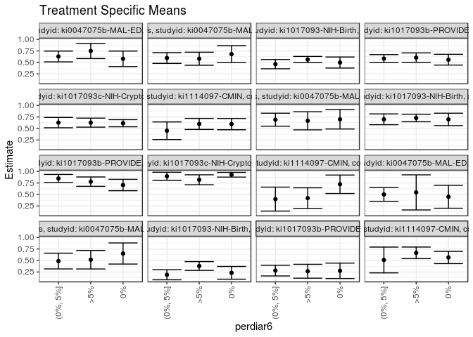

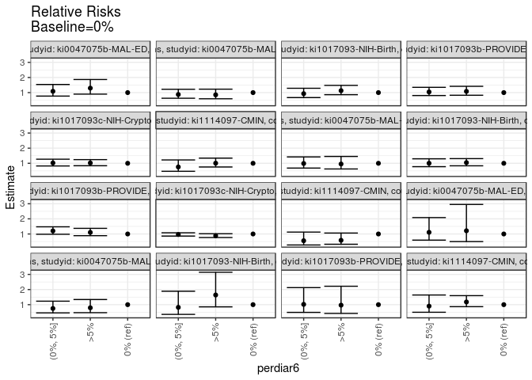

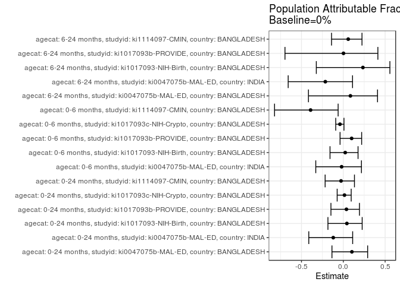

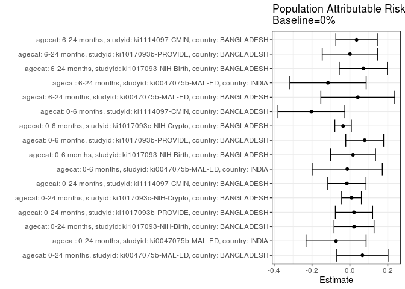

## Results Table

### Parameter: TSM

| agecat | studyid | country | intervention_level | baseline_level | estimate | ci_lower | ci_upper |
| --- | --- | --- | --- | --- | --- | --- | --- |
| 0-24 months | ki0047075b-MAL-ED | BANGLADESH | 0% | NA | 0.5789474 | 0.4106093 | 0.7472854 |
| 0-24 months | ki0047075b-MAL-ED | BANGLADESH | (0%, 5%] | NA | 0.6296296 | 0.5121519 | 0.7471074 |
| 0-24 months | ki0047075b-MAL-ED | BANGLADESH | >5% | NA | 0.7500000 | 0.5844253 | 0.9155747 |
| 0-24 months | ki0047075b-MAL-ED | INDIA | 0% | NA | 0.6807283 | 0.4973873 | 0.8640694 |
| 0-24 months | ki0047075b-MAL-ED | INDIA | (0%, 5%] | NA | 0.5957131 | 0.4787119 | 0.7127143 |
| 0-24 months | ki0047075b-MAL-ED | INDIA | >5% | NA | 0.5805479 | 0.4388144 | 0.7222814 |
| 0-24 months | ki1017093-NIH-Birth | BANGLADESH | 0% | NA | 0.4980702 | 0.3780832 | 0.6180572 |
| 0-24 months | ki1017093-NIH-Birth | BANGLADESH | (0%, 5%] | NA | 0.4627603 | 0.3617619 | 0.5637587 |
| 0-24 months | ki1017093-NIH-Birth | BANGLADESH | >5% | NA | 0.5625405 | 0.4944460 | 0.6306350 |
| 0-24 months | ki1017093b-PROVIDE | BANGLADESH | 0% | NA | 0.5593941 | 0.4422505 | 0.6765376 |
| 0-24 months | ki1017093b-PROVIDE | BANGLADESH | (0%, 5%] | NA | 0.5836218 | 0.4970275 | 0.6702161 |
| 0-24 months | ki1017093b-PROVIDE | BANGLADESH | >5% | NA | 0.6050043 | 0.5024794 | 0.7075292 |
| 0-24 months | ki1017093c-NIH-Crypto | BANGLADESH | 0% | NA | 0.6138269 | 0.5364410 | 0.6912128 |
| 0-24 months | ki1017093c-NIH-Crypto | BANGLADESH | (0%, 5%] | NA | 0.6272700 | 0.5148537 | 0.7396862 |
| 0-24 months | ki1017093c-NIH-Crypto | BANGLADESH | >5% | NA | 0.6264816 | 0.5282888 | 0.7246744 |
| 0-24 months | ki1114097-CMIN | BANGLADESH | 0% | NA | 0.5946147 | 0.4719954 | 0.7172340 |
| 0-24 months | ki1114097-CMIN | BANGLADESH | (0%, 5%] | NA | 0.4507965 | 0.2595406 | 0.6420523 |
| 0-24 months | ki1114097-CMIN | BANGLADESH | >5% | NA | 0.5985906 | 0.4787611 | 0.7184201 |
| 0-6 months | ki0047075b-MAL-ED | INDIA | 0% | NA | 0.7000000 | 0.4880703 | 0.9119297 |
| 0-6 months | ki0047075b-MAL-ED | INDIA | (0%, 5%] | NA | 0.6904762 | 0.5490691 | 0.8318832 |
| 0-6 months | ki0047075b-MAL-ED | INDIA | >5% | NA | 0.6666667 | 0.4697615 | 0.8635719 |
| 0-6 months | ki1017093-NIH-Birth | BANGLADESH | 0% | NA | 0.6966614 | 0.5617492 | 0.8315737 |
| 0-6 months | ki1017093-NIH-Birth | BANGLADESH | (0%, 5%] | NA | 0.6985948 | 0.5813416 | 0.8158479 |
| 0-6 months | ki1017093-NIH-Birth | BANGLADESH | >5% | NA | 0.7279868 | 0.6459494 | 0.8100242 |
| 0-6 months | ki1017093b-PROVIDE | BANGLADESH | 0% | NA | 0.7058083 | 0.5826346 | 0.8289819 |
| 0-6 months | ki1017093b-PROVIDE | BANGLADESH | (0%, 5%] | NA | 0.8488766 | 0.7617697 | 0.9359834 |
| 0-6 months | ki1017093b-PROVIDE | BANGLADESH | >5% | NA | 0.7788585 | 0.6770336 | 0.8806834 |
| 0-6 months | ki1017093c-NIH-Crypto | BANGLADESH | 0% | NA | 0.9292929 | 0.8781896 | 0.9803962 |
| 0-6 months | ki1017093c-NIH-Crypto | BANGLADESH | (0%, 5%] | NA | 0.8958333 | 0.8083040 | 0.9833626 |
| 0-6 months | ki1017093c-NIH-Crypto | BANGLADESH | >5% | NA | 0.8200000 | 0.7121415 | 0.9278585 |
| 0-6 months | ki1114097-CMIN | BANGLADESH | 0% | NA | 0.7222222 | 0.5220936 | 0.9223508 |
| 0-6 months | ki1114097-CMIN | BANGLADESH | (0%, 5%] | NA | 0.4000000 | 0.1395476 | 0.6604524 |
| 0-6 months | ki1114097-CMIN | BANGLADESH | >5% | NA | 0.4210526 | 0.1965983 | 0.6455070 |
| 6-24 months | ki0047075b-MAL-ED | BANGLADESH | 0% | NA | 0.4500000 | 0.2011920 | 0.6988080 |
| 6-24 months | ki0047075b-MAL-ED | BANGLADESH | (0%, 5%] | NA | 0.5000000 | 0.3500866 | 0.6499134 |
| 6-24 months | ki0047075b-MAL-ED | BANGLADESH | >5% | NA | 0.5454545 | 0.1641333 | 0.9267758 |
| 6-24 months | ki0047075b-MAL-ED | INDIA | 0% | NA | 0.6521739 | 0.4227678 | 0.8815800 |
| 6-24 months | ki0047075b-MAL-ED | INDIA | (0%, 5%] | NA | 0.4883721 | 0.3173946 | 0.6593495 |
| 6-24 months | ki0047075b-MAL-ED | INDIA | >5% | NA | 0.5172414 | 0.3159219 | 0.7185608 |
| 6-24 months | ki1017093-NIH-Birth | BANGLADESH | 0% | NA | 0.2320166 | 0.0936260 | 0.3704071 |
| 6-24 months | ki1017093-NIH-Birth | BANGLADESH | (0%, 5%] | NA | 0.1907371 | 0.0808764 | 0.3005978 |
| 6-24 months | ki1017093-NIH-Birth | BANGLADESH | >5% | NA | 0.3805062 | 0.2846246 | 0.4763877 |
| 6-24 months | ki1017093b-PROVIDE | BANGLADESH | 0% | NA | 0.2758621 | 0.1082883 | 0.4434359 |
| 6-24 months | ki1017093b-PROVIDE | BANGLADESH | (0%, 5%] | NA | 0.2812500 | 0.1643962 | 0.3981038 |
| 6-24 months | ki1017093b-PROVIDE | BANGLADESH | >5% | NA | 0.2666667 | 0.1154539 | 0.4178794 |
| 6-24 months | ki1114097-CMIN | BANGLADESH | 0% | NA | 0.5661270 | 0.4332222 | 0.6990319 |
| 6-24 months | ki1114097-CMIN | BANGLADESH | (0%, 5%] | NA | 0.5113738 | 0.2309996 | 0.7917480 |
| 6-24 months | ki1114097-CMIN | BANGLADESH | >5% | NA | 0.6666399 | 0.5406386 | 0.7926411 |

### Parameter: E(Y)

| agecat | studyid | country | intervention_level | baseline_level | estimate | ci_lower | ci_upper |
| --- | --- | --- | --- | --- | --- | --- | --- |
| 0-24 months | ki0047075b-MAL-ED | BANGLADESH | NA | NA | 0.6451613 | 0.5593015 | 0.7310211 |
| 0-24 months | ki0047075b-MAL-ED | INDIA | NA | NA | 0.6077348 | 0.5286689 | 0.6868008 |
| 0-24 months | ki1017093-NIH-Birth | BANGLADESH | NA | NA | 0.5201900 | 0.4695846 | 0.5707955 |
| 0-24 months | ki1017093b-PROVIDE | BANGLADESH | NA | NA | 0.5811688 | 0.5245443 | 0.6377934 |
| 0-24 months | ki1017093c-NIH-Crypto | BANGLADESH | NA | NA | 0.6225806 | 0.5684562 | 0.6767051 |
| 0-24 months | ki1114097-CMIN | BANGLADESH | NA | NA | 0.5789474 | 0.5004470 | 0.6574477 |
| 0-6 months | ki0047075b-MAL-ED | INDIA | NA | NA | 0.6860465 | 0.5849088 | 0.7871842 |
| 0-6 months | ki1017093-NIH-Birth | BANGLADESH | NA | NA | 0.7130045 | 0.6535890 | 0.7724200 |
| 0-6 months | ki1017093b-PROVIDE | BANGLADESH | NA | NA | 0.7837838 | 0.7252863 | 0.8422812 |
| 0-6 months | ki1017093c-NIH-Crypto | BANGLADESH | NA | NA | 0.8934010 | 0.8497799 | 0.9370221 |
| 0-6 months | ki1114097-CMIN | BANGLADESH | NA | NA | 0.5192308 | 0.3806687 | 0.6577929 |
| 6-24 months | ki0047075b-MAL-ED | BANGLADESH | NA | NA | 0.4918033 | 0.3610932 | 0.6225134 |
| 6-24 months | ki0047075b-MAL-ED | INDIA | NA | NA | 0.5368421 | 0.4223932 | 0.6512910 |
| 6-24 months | ki1017093-NIH-Birth | BANGLADESH | NA | NA | 0.3030303 | 0.2377927 | 0.3682679 |
| 6-24 months | ki1017093b-PROVIDE | BANGLADESH | NA | NA | 0.2764228 | 0.1950773 | 0.3577682 |
| 6-24 months | ki1114097-CMIN | BANGLADESH | NA | NA | 0.6014493 | 0.5131344 | 0.6897641 |

### Parameter: RR

| agecat | studyid | country | intervention_level | baseline_level | estimate | ci_lower | ci_upper |
| --- | --- | --- | --- | --- | --- | --- | --- |
| 0-24 months | ki0047075b-MAL-ED | BANGLADESH | 0% | 0% | 1.0000000 | 1.0000000 | 1.000000 |
| 0-24 months | ki0047075b-MAL-ED | BANGLADESH | (0%, 5%] | 0% | 1.0875421 | 0.7699799 | 1.536076 |
| 0-24 months | ki0047075b-MAL-ED | BANGLADESH | >5% | 0% | 1.2954545 | 0.8993242 | 1.866071 |
| 0-24 months | ki0047075b-MAL-ED | INDIA | 0% | 0% | 1.0000000 | 1.0000000 | 1.000000 |
| 0-24 months | ki0047075b-MAL-ED | INDIA | (0%, 5%] | 0% | 0.8751114 | 0.6273482 | 1.220725 |
| 0-24 months | ki0047075b-MAL-ED | INDIA | >5% | 0% | 0.8528335 | 0.5921848 | 1.228206 |
| 0-24 months | ki1017093-NIH-Birth | BANGLADESH | 0% | 0% | 1.0000000 | 1.0000000 | 1.000000 |
| 0-24 months | ki1017093-NIH-Birth | BANGLADESH | (0%, 5%] | 0% | 0.9291066 | 0.6704291 | 1.287592 |
| 0-24 months | ki1017093-NIH-Birth | BANGLADESH | >5% | 0% | 1.1294402 | 0.8630355 | 1.478080 |
| 0-24 months | ki1017093b-PROVIDE | BANGLADESH | 0% | 0% | 1.0000000 | 1.0000000 | 1.000000 |
| 0-24 months | ki1017093b-PROVIDE | BANGLADESH | (0%, 5%] | 0% | 1.0433106 | 0.8067215 | 1.349285 |
| 0-24 months | ki1017093b-PROVIDE | BANGLADESH | >5% | 0% | 1.0815351 | 0.8260491 | 1.416039 |
| 0-24 months | ki1017093c-NIH-Crypto | BANGLADESH | 0% | 0% | 1.0000000 | 1.0000000 | 1.000000 |
| 0-24 months | ki1017093c-NIH-Crypto | BANGLADESH | (0%, 5%] | 0% | 1.0219005 | 0.8227005 | 1.269333 |
| 0-24 months | ki1017093c-NIH-Crypto | BANGLADESH | >5% | 0% | 1.0206161 | 0.8391892 | 1.241266 |
| 0-24 months | ki1114097-CMIN | BANGLADESH | 0% | 0% | 1.0000000 | 1.0000000 | 1.000000 |
| 0-24 months | ki1114097-CMIN | BANGLADESH | (0%, 5%] | 0% | 0.7581321 | 0.4709684 | 1.220388 |
| 0-24 months | ki1114097-CMIN | BANGLADESH | >5% | 0% | 1.0066865 | 0.7549668 | 1.342334 |
| 0-6 months | ki0047075b-MAL-ED | INDIA | 0% | 0% | 1.0000000 | 1.0000000 | 1.000000 |
| 0-6 months | ki0047075b-MAL-ED | INDIA | (0%, 5%] | 0% | 0.9863946 | 0.6843974 | 1.421651 |
| 0-6 months | ki0047075b-MAL-ED | INDIA | >5% | 0% | 0.9523810 | 0.6239074 | 1.453789 |
| 0-6 months | ki1017093-NIH-Birth | BANGLADESH | 0% | 0% | 1.0000000 | 1.0000000 | 1.000000 |
| 0-6 months | ki1017093-NIH-Birth | BANGLADESH | (0%, 5%] | 0% | 1.0027751 | 0.7757823 | 1.296186 |
| 0-6 months | ki1017093-NIH-Birth | BANGLADESH | >5% | 0% | 1.0449649 | 0.8347870 | 1.308060 |
| 0-6 months | ki1017093b-PROVIDE | BANGLADESH | 0% | 0% | 1.0000000 | 1.0000000 | 1.000000 |
| 0-6 months | ki1017093b-PROVIDE | BANGLADESH | (0%, 5%] | 0% | 1.2027014 | 0.9819305 | 1.473109 |
| 0-6 months | ki1017093b-PROVIDE | BANGLADESH | >5% | 0% | 1.1034987 | 0.8872284 | 1.372487 |
| 0-6 months | ki1017093c-NIH-Crypto | BANGLADESH | 0% | 0% | 1.0000000 | 1.0000000 | 1.000000 |
| 0-6 months | ki1017093c-NIH-Crypto | BANGLADESH | (0%, 5%] | 0% | 0.9639946 | 0.8617509 | 1.078369 |
| 0-6 months | ki1017093c-NIH-Crypto | BANGLADESH | >5% | 0% | 0.8823913 | 0.7651472 | 1.017601 |
| 0-6 months | ki1114097-CMIN | BANGLADESH | 0% | 0% | 1.0000000 | 1.0000000 | 1.000000 |
| 0-6 months | ki1114097-CMIN | BANGLADESH | (0%, 5%] | 0% | 0.5538462 | 0.2729382 | 1.123865 |
| 0-6 months | ki1114097-CMIN | BANGLADESH | >5% | 0% | 0.5829960 | 0.3197555 | 1.062950 |
| 6-24 months | ki0047075b-MAL-ED | BANGLADESH | 0% | 0% | 1.0000000 | 1.0000000 | 1.000000 |
| 6-24 months | ki0047075b-MAL-ED | BANGLADESH | (0%, 5%] | 0% | 1.1111111 | 0.5923791 | 2.084084 |
| 6-24 months | ki0047075b-MAL-ED | BANGLADESH | >5% | 0% | 1.2121212 | 0.4972345 | 2.954819 |
| 6-24 months | ki0047075b-MAL-ED | INDIA | 0% | 0% | 1.0000000 | 1.0000000 | 1.000000 |
| 6-24 months | ki0047075b-MAL-ED | INDIA | (0%, 5%] | 0% | 0.7488372 | 0.4558306 | 1.230188 |
| 6-24 months | ki0047075b-MAL-ED | INDIA | >5% | 0% | 0.7931034 | 0.4694408 | 1.339920 |
| 6-24 months | ki1017093-NIH-Birth | BANGLADESH | 0% | 0% | 1.0000000 | 1.0000000 | 1.000000 |
| 6-24 months | ki1017093-NIH-Birth | BANGLADESH | (0%, 5%] | 0% | 0.8220840 | 0.3578531 | 1.888546 |
| 6-24 months | ki1017093-NIH-Birth | BANGLADESH | >5% | 0% | 1.6399958 | 0.8558460 | 3.142605 |
| 6-24 months | ki1017093b-PROVIDE | BANGLADESH | 0% | 0% | 1.0000000 | 1.0000000 | 1.000000 |
| 6-24 months | ki1017093b-PROVIDE | BANGLADESH | (0%, 5%] | 0% | 1.0195312 | 0.4883689 | 2.128399 |
| 6-24 months | ki1017093b-PROVIDE | BANGLADESH | >5% | 0% | 0.9666667 | 0.4210787 | 2.219168 |
| 6-24 months | ki1114097-CMIN | BANGLADESH | 0% | 0% | 1.0000000 | 1.0000000 | 1.000000 |
| 6-24 months | ki1114097-CMIN | BANGLADESH | (0%, 5%] | 0% | 0.9032845 | 0.4980769 | 1.638147 |
| 6-24 months | ki1114097-CMIN | BANGLADESH | >5% | 0% | 1.1775446 | 0.8685374 | 1.596490 |

### Parameter: PAR

| agecat | studyid | country | intervention_level | baseline_level | estimate | ci_lower | ci_upper |
| --- | --- | --- | --- | --- | --- | --- | --- |
| 0-24 months | ki0047075b-MAL-ED | BANGLADESH | 0% | NA | 0.0662139 | -0.0688583 | 0.2012861 |
| 0-24 months | ki0047075b-MAL-ED | INDIA | 0% | NA | -0.0729935 | -0.2315621 | 0.0855750 |
| 0-24 months | ki1017093-NIH-Birth | BANGLADESH | 0% | NA | 0.0221198 | -0.0833894 | 0.1276291 |
| 0-24 months | ki1017093b-PROVIDE | BANGLADESH | 0% | NA | 0.0217748 | -0.0765813 | 0.1201308 |
| 0-24 months | ki1017093c-NIH-Crypto | BANGLADESH | 0% | NA | 0.0087538 | -0.0433123 | 0.0608198 |
| 0-24 months | ki1114097-CMIN | BANGLADESH | 0% | NA | -0.0156673 | -0.1164545 | 0.0851199 |
| 0-6 months | ki0047075b-MAL-ED | INDIA | 0% | NA | -0.0139535 | -0.1990284 | 0.1711214 |
| 0-6 months | ki1017093-NIH-Birth | BANGLADESH | 0% | NA | 0.0163430 | -0.1024700 | 0.1351561 |
| 0-6 months | ki1017093b-PROVIDE | BANGLADESH | 0% | NA | 0.0779755 | -0.0217834 | 0.1777344 |
| 0-6 months | ki1017093c-NIH-Crypto | BANGLADESH | 0% | NA | -0.0358919 | -0.0793847 | 0.0076008 |
| 0-6 months | ki1114097-CMIN | BANGLADESH | 0% | NA | -0.2029915 | -0.3793059 | -0.0266770 |
| 6-24 months | ki0047075b-MAL-ED | BANGLADESH | 0% | NA | 0.0418033 | -0.1531482 | 0.2367548 |
| 6-24 months | ki0047075b-MAL-ED | INDIA | 0% | NA | -0.1153318 | -0.3165243 | 0.0858607 |
| 6-24 months | ki1017093-NIH-Birth | BANGLADESH | 0% | NA | 0.0710137 | -0.0560546 | 0.1980821 |
| 6-24 months | ki1017093b-PROVIDE | BANGLADESH | 0% | NA | 0.0005607 | -0.1459375 | 0.1470589 |
| 6-24 months | ki1114097-CMIN | BANGLADESH | 0% | NA | 0.0353222 | -0.0739067 | 0.1445511 |

### Parameter: PAF

| agecat | studyid | country | intervention_level | baseline_level | estimate | ci_lower | ci_upper |
| --- | --- | --- | --- | --- | --- | --- | --- |
| 0-24 months | ki0047075b-MAL-ED | BANGLADESH | 0% | NA | 0.1026316 | -0.1357451 | 0.2909764 |
| 0-24 months | ki0047075b-MAL-ED | INDIA | 0% | NA | -0.1201075 | -0.4127614 | 0.1119230 |
| 0-24 months | ki1017093-NIH-Birth | BANGLADESH | 0% | NA | 0.0425226 | -0.1837786 | 0.2255621 |
| 0-24 months | ki1017093b-PROVIDE | BANGLADESH | 0% | NA | 0.0374672 | -0.1479369 | 0.1929266 |
| 0-24 months | ki1017093c-NIH-Crypto | BANGLADESH | 0% | NA | 0.0140605 | -0.0733101 | 0.0943188 |
| 0-24 months | ki1114097-CMIN | BANGLADESH | 0% | NA | -0.0270618 | -0.2171713 | 0.1333546 |
| 0-6 months | ki0047075b-MAL-ED | INDIA | 0% | NA | -0.0203390 | -0.3291105 | 0.2167005 |
| 0-6 months | ki1017093-NIH-Birth | BANGLADESH | 0% | NA | 0.0229214 | -0.1588708 | 0.1761958 |
| 0-6 months | ki1017093b-PROVIDE | BANGLADESH | 0% | NA | 0.0994860 | -0.0387864 | 0.2193530 |
| 0-6 months | ki1017093c-NIH-Crypto | BANGLADESH | 0% | NA | -0.0401745 | -0.0906918 | 0.0080031 |
| 0-6 months | ki1114097-CMIN | BANGLADESH | 0% | NA | -0.3909465 | -0.8220742 | -0.0618295 |
| 6-24 months | ki0047075b-MAL-ED | BANGLADESH | 0% | NA | 0.0850000 | -0.4167715 | 0.4090614 |
| 6-24 months | ki0047075b-MAL-ED | INDIA | 0% | NA | -0.2148338 | -0.6589228 | 0.1103739 |
| 6-24 months | ki1017093-NIH-Birth | BANGLADESH | 0% | NA | 0.2343453 | -0.3226518 | 0.5567790 |
| 6-24 months | ki1017093b-PROVIDE | BANGLADESH | 0% | NA | 0.0020284 | -0.6972781 | 0.4132091 |
| 6-24 months | ki1114097-CMIN | BANGLADESH | 0% | NA | 0.0587285 | -0.1407107 | 0.2232982 |